# Loading Single-cell RNA-seq Data

Single-cell RNA-seq

Quality Control

R

Python

In this lesson, participants learn how to load single‑cell RNA‑seq count data. The lesson introduces the structure of typical 10X Genomics output files and how to import these files for multiple samples into R/Python. Participants explore the structure of the single-cell object. By the end, participants will be able to prepare their data for downstream quality control and analysis.

Authors

Mary Piper

Meeta Mistry

Radhika Khetani

Lorena Pantano

Jihe Liu

Will Gammerdinger

Noor Sohail

Published

June 17, 2026

Keywords

data import, 10X Genomics, Seurat, scanpy

Approximate time: 90 minutes

## Learning objectives

In this lesson, we will:

- Set-up the environment for a single-cell analysis.
- Establish good data management and metadata practices.
- Demonstrate how to import data and set up a project for upcoming quality control analysis.

## Overview of lesson

To begin a standard single-cell analysis, we must first understand the dataset we are working with. Then, assuming the data has already been generated, we must load the gene expression counts into our programming language of choice (R or Python). This will enable us to move on to the next step of the workflow, which is assessing the quality of the data to *filter cells using quality metrics*.

## Exploring the example dataset

For this workshop, we will be working with a single-cell RNA-seq dataset which is part of a larger study from [Kang et al. (2017)](https://www.nature.com/articles/nbt.4042). In this paper, the authors present a computational algorithm that harnesses genetic variation (eQTL) to determine the genetic identity of each droplet containing a single cell (singlet) and identify droplets containing two cells from different individuals (doublets).

The data used to test their algorithm consists of pooled Peripheral Blood Mononuclear Cells (PBMCs) taken from eight lupus patients, split into control and interferon beta-treated (stimulated) conditions.

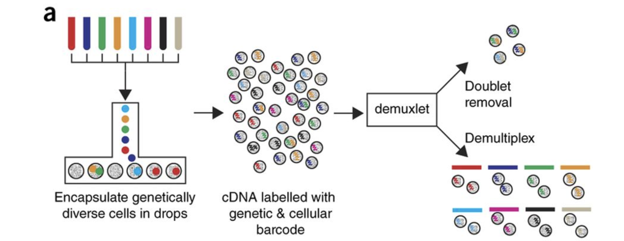

Figure 2: Overview of the Kang et al. (2017) pooled PBMC single-cell RNA-seq study design.  
*Image credit: [Kang et al. (2017)](https://www.nature.com/articles/nbt.4042)*

**Downloading the raw data**

This dataset is available on GEO (GSE96583), however the available counts matrix lacked mitochondrial reads, so we downloaded the BAM files from the SRA (SRP102802). These BAM files were converted back to FASTQ files, then run through [Cell Ranger](https://support.10xgenomics.com/single-cell-gene-expression/software/pipelines/latest/what-is-cell-ranger) to obtain the count data that we will be using.

The count data for this dataset is also freely available from 10X Genomics and in several popular tutorials, including the [Seurat PBMC tutorial](https://satijalab.org/seurat/v3.0/immune_alignment.html).

### Metadata

In addition to the raw data, we also need to collect **information about the data**; this is known as **metadata**. There is often a temptation to just start exploring the data, but it is not very meaningful if we know nothing about the samples the data originated from.

Some relevant experimental metadata for our dataset is provided below:

- PBMC samples from eight individual lupus patients were separated into two aliquots each.
- One aliquot of PBMCs was activated by 100 U/mL of recombinant IFN-β for 6 hours and the second aliquot was left untreated.
- After 6 hours, the eight samples for each condition were pooled together in two final pools (stimulated cells and control cells). We will be working with these two, pooled samples.
- The libraries were prepared using 10X Genomics version 2 chemistry and sequenced on the Illumina NextSeq 500.
- 12,138 and 12,167 cells were identified (after removing doublets) for control and stimulated pooled samples, respectively.

**Pooling samples together**

We did not demultiplex the samples because SNP genotype information was used to demultiplex in the paper and the barcodes/sample IDs were not readily available for this data. Generally, you would **demultiplex and perform QC on each individual sample** rather than pooling the samples.

Therefore we are unable to identify which of the eight individuals a cell comes from for this example analysis.

**It is recommended that you have some expectation regarding the cell types you expect to see in a dataset prior to performing the QC.** This will inform you if you have any cell types with low complexity (lots of transcripts from a few genes) or cells with higher levels of mitochondrial expression. This will enable us to account for these biological factors during the analysis workflow.

Since the samples are PBMCs, we will expect immune cells, such as:

- B cells
- T cells
- NK cells
- Monocytes
- Macrophages
- Possibly megakaryocytes

None of the above cell types are expected to be low complexity or anticipated to have high mitochondrial content.

**Exercise 1**

1. Given the information that we know from the metadata, what might be some questions that we want to answer using our data?
2. What are some of the limitations of this dataset that we should keep in mind as we analyze it?

## Set up

For this workshop, we will be working with the files and folders that have been pre-generated for you.

**Download data**

If you haven’t done this already, the project can be accessed using [this link](https://www.dropbox.com/scl/fi/pnnlp0pyaqbrqbfyfoidu/scrna_python_r_update.zip?rlkey=gz03gsqvg0l74fsxnwalw86mm&dl=1).

Once downloaded, you should see a file called `scrna_python_r_update.zip` on your computer (likely, in your `Downloads` folder).

1. Unzip this file. It will result in a folder of the same name.
2. **Move the folder to the location on your computer where you would like to perform the analysis.** We typically recommend putting it in the `Desktop` folder.
3. Unzip the `scrna_python_r_update` folder and open it.

[figure not shown]

Figure 3: Project directory structure for the `single_cell_rnaseq` workshop materials.

The `data/` folder is already populated with the input files that will be used throughout the workshop.

**Note for Windows OS users**

When you open the project folder after unzipping, please check if you have a `data` folder with a subfolder also called `data`. If this is the case, please move all the files from the subfolder into the parent `data` folder.

### Project organization

One of the most important parts of research that involves large amounts of data is how best to manage it. We tend to prioritize the analysis, but there are many other important aspects of **data management that are often overlooked** in the excitement to get a first look at new data. The [HMS Data Management Working Group](https://datamanagement.hms.harvard.edu/), discusses in-depth some things to consider beyond the data creation and analysis.

One important aspect of data management is organization. For each experiment you work on and analyze data for, it is considered best practice to get organized by creating **a planned storage space (directory structure)**. We will do that for our single-cell analysis.

Look inside your project space and you will find that a directory structure has been set-up for you:

```r
scrna_python_r_update/
├── data
├── figures
└── results
```

### New script and loading libraries

**R**

**Locate the `.Rproj file` and double-click on it.** This will open up RStudio with the “single_cell_rnaseq” project loaded. Next, open a new Rscript file, and start with some comments to indicate what this file is going to contain:

```r
# Load 10x single-cell data
# Introduction to single-cell RNA-seq workshop
# Author: Harvard Chan Bioinformatics Core
# June 2026
```

Save the Rscript as `quality_control.R`. Your working directory should look something like this:

[figure not shown]

Figure 4: RStudio interface with the `single_cell_rnaseq` project opened.

Now, we can load the necessary libraries:

```r
# Load libraries
library(Seurat)
library(tidyverse)
```

**Python**

Open Anaconda Navigator and set the environment to the `intro_scRNAseq` environment that we installed all our packages into. Then hit the “Launch” button under Jupyter Lab to open the notebook interface.

[figure not shown]

Figure 5: Anaconda Navigator, with conda environment and launch button for Jupyter Lab highlighted.

In the File Explorer of Jupyter Lab, navigate to where you downloaded and unzipped the files in the previous step. In the screenshot here, you can see that we navigated to “Desktop” -> “scrna_python_r_update”:

[figure not shown]

Figure 6: File explorer with Jupyter Lab, navigating to where the downloaded `scrna_python_r_update` folder is stored.

**The `single_cell_rnaseq.Rproj` file**

For the Python version of this workshop, we will **ignore** the `single_cell_rnaseq.Rproj` file. This is meant to be used with the R based workflow and is not applicable for the python instructions.

Now that we are in the correct project directory, we can create a new Jupyter Lab notebook to begin programming.

[figure not shown]

Figure 7: Create a new “Notebook” from the “File” tab of Jupyter Lab.

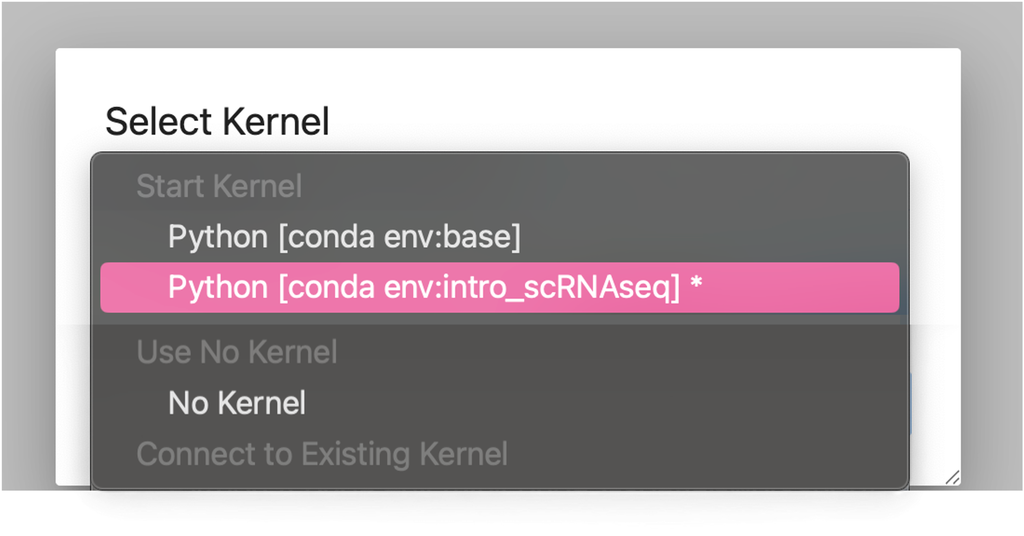

Rename the notebook to be `quality_control.ipynb`.

[figure not shown]

Figure 9: Rename the new `Untitled.ipynb` file to `quality_control.ipynb`.

In the first cell, we are going to add some comments to indicate what this file is going to contain:

```python
# Load 10x single-cell data
# Introduction to single-cell RNA-seq workshop
# Author: Harvard Chan Bioinformatics Core
# June 2026
```

Next, we can import the necessary packages:

```python
# Load packages
import scanpy as sc
import numpy as np
import seaborn as sns
import anndata
import matplotlib.pyplot as plt
```

Which should give a Jupyter Notebook that looks like this:

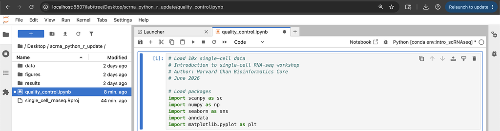

Figure 10: Final set-up of Jupyter Notebook for the scRNA-seq workshop.

## Data files used as input

After processing 10X data using its proprietary software Cell Ranger, you will have an `outs` directory (always). Within this directory you will find a number of different files including the files listed below:

[output not shown]

While Cell Ranger performs filtering on the expression counts (see note below), we wish to perform our own QC and filtering because we want to account for the biology of our experiment/biological system. Given this, **we are only interested in the `raw_feature_bc_matrix` folder** in the Cell Ranger output.

**Why don’t we use the `filtered_feature_bc_matrix` folder?**

The `filtered_feature_bc_matrix` uses [internal filtering criteria by Cell Ranger](https://support.10xgenomics.com/single-cell-gene-expression/software/pipelines/latest/algorithms/overview), and we do not have control of what cells to keep or abandon.

The filtering performed by Cell Ranger when generating the `filtered_feature_bc_matrix` is often good; however, sometimes data can be of very high quality and the Cell Ranger filtering process can remove high quality cells.

In addition, it is generally preferable to explore your own data while taking into account the biology of the experiment for applying thresholds during filtering. For example, if you expect a particular cell type in your dataset to be smaller and/or not as transcriptionally active as other cell types in your dataset, these cells have the potential to be filtered out. However, with Cell Ranger v3 they have tried to account for cells of different sizes (for example, tumor vs infiltrating lymphocytes), and now may not filter as many low quality cells as needed.

Regardless of the technology or pipeline used to process your raw single-cell RNA-seq sequence data, the output with quantified expression will generally be the same. That is, for each individual sample you will have the following **three files**:

1. A file with the **cell IDs**, representing all cells quantified
2. A file with the **gene IDs**, representing all genes quantified
3. A **matrix of counts** per gene for every cell

We can explore these files by clicking the `data/ctrl_raw_feature_bc_matrix` folder:

### `barcodes.tsv`

This is a text file which contains all cellular barcodes present for that sample. Barcodes are listed in the order of data presented in the matrix file (i.e. these are the column names).

Table 1: First several rows of the `barcodes.tsv.gz` file

| X1 |
| --- |
| AAACATACAAAACG-1 |
| AAACATACAAAAGC-1 |
| AAACATACAAACAG-1 |
| AAACATACAAACGA-1 |
| AAACATACAAAGCA-1 |
| AAACATACAAAGTG-1 |

### `features.tsv`

This is a text file which contains the identifiers of the quantified genes. The source of the identifier can vary depending on what reference (i.e. Ensembl, NCBI, UCSC) you use in the quantification methods, but most often these are official gene symbols. The order of these genes corresponds to the order of the rows in the matrix file (i.e. these are the row names).

Table 2: First several rows of the `features.tsv.gz` file

| X1 | X2 | X3 |
| --- | --- | --- |
| ENSG00000243485 | MIR1302-2HG | Gene Expression |
| ENSG00000237613 | FAM138A | Gene Expression |
| ENSG00000186092 | OR4F5 | Gene Expression |
| ENSG00000238009 | AL627309.1 | Gene Expression |
| ENSG00000239945 | AL627309.3 | Gene Expression |
| ENSG00000239906 | AL627309.2 | Gene Expression |

### `matrix.mtx`

This is a text file which contains a matrix of count values. The rows are associated with the gene IDs above and columns correspond to the cellular barcodes. Note that there are **many zero values** in this matrix.

Table 3: First 10 rows and columns of the `matrix.mtx.gz` file

| V1 | V2 | V3 | V4 | V5 | V6 | V7 | V8 | V9 | V10 |
| --- | --- | --- | --- | --- | --- | --- | --- | --- | --- |
| 0 | 0 | 0 | 0 | 0 | 0 | 0 | 0 | 0 | 0 |
| 0 | 0 | 0 | 0 | 0 | 0 | 0 | 0 | 0 | 0 |
| 0 | 0 | 0 | 0 | 0 | 0 | 0 | 0 | 0 | 0 |
| 0 | 0 | 0 | 0 | 0 | 0 | 0 | 0 | 0 | 0 |
| 0 | 0 | 0 | 0 | 0 | 0 | 0 | 0 | 0 | 0 |
| 0 | 0 | 0 | 0 | 0 | 0 | 0 | 0 | 0 | 0 |
| 0 | 0 | 0 | 0 | 0 | 0 | 0 | 0 | 0 | 0 |
| 0 | 0 | 0 | 0 | 0 | 0 | 0 | 0 | 0 | 0 |
| 0 | 0 | 0 | 0 | 0 | 0 | 0 | 0 | 0 | 0 |
| 0 | 0 | 0 | 0 | 0 | 0 | 0 | 0 | 0 | 0 |

Loading this data requires us to **use functions that allow us to efficiently combine these three files into a single count matrix.** However, instead of creating a regular matrix data structure, the functions we will use create a **sparse matrix** to reduce the amount of memory (RAM), processing capacity (CPU) and storage required to work with our huge count matrix.

Different methods for reading in data include:

- Reading into the `matrix.mtx` file directly to manually create our single-cell object (AnnData or Seurat). This requires also reading in the `features.tsv` and `barcodes.tsv` as tables to supply the barcodes and gene names. For specific code and instructions on how to do this in **R** please see these additional material.
- Many packages have built-in functions to load a CellRanger directory as input directly. With this method individual files do not need to be loaded in, instead the function will load and combine them into a sparse matrix.
  - **`Read10X()`** for Seurat
  - **`read_10x_mtx()`** for scanpy

**We will be using the built-in functions to load in our data!**

## Reading in a single sample

If we had a single sample, we could generate the count matrix and then subsequently create our object:

**R**

The Seurat object is a custom list-like object that has well-defined spaces to store specific information/data. You can find more information about the slots in the Seurat object [at this link](https://github.com/satijalab/seurat/wiki/Seurat).

```r
# How to read in 10X data for a single sample (output is a sparse matrix)
ctrl_counts <- Read10X(data.dir = "data/ctrl_raw_feature_bc_matrix")

# Turn count matrix into a Seurat object (output is a Seurat object)
ctrl <- CreateSeuratObject(counts = ctrl_counts,
                           min.features = 100)
ctrl
```

```
An object of class Seurat
33538 features across 15688 samples within 1 assay
Active assay: RNA (33538 features, 0 variable features)
 1 layer present: counts
```

**`min.features` argument**

The `min.features` argument specifies the minimum number of genes that need to be detected per cell. This argument will filter out poor quality cells that likely just have random barcodes encapsulated without any cell present. Usually, cells with less than 100 genes detected are not considered for analysis.

**Seurat automatically creates some metadata** for each of the cells when you use the `Read10X()` function to read in data. This information is stored in the `meta.data` slot within the Seurat object.

```r
# Explore the metadata
head(ctrl@meta.data)
```

Table 4: First several rows of a the `ctrl@meta.data`

|  | orig.ident | nCount_RNA | nFeature_RNA |
| --- | --- | --- | --- |
| AAACATACAATGCC-1 | SeuratProject | 2344 | 874 |
| AAACATACATTTCC-1 | SeuratProject | 3125 | 896 |
| AAACATACCAGAAA-1 | SeuratProject | 2578 | 725 |
| AAACATACCAGCTA-1 | SeuratProject | 3261 | 979 |
| AAACATACCATGCA-1 | SeuratProject | 746 | 362 |
| AAACATACCTCGCT-1 | SeuratProject | 3519 | 866 |

**Python**

[Scanpy](https://scanpy.scverse.org/en/stable/) is the Python package that we will be using. It is built upon an `AnnData` object, which is a data structure that can efficiently store our single-cell information. It has has slots that are meant to contain very specific pieces of information, shown here:

[figure not shown]

Figure 11: Schematic of the AnnData object with main components `.X` counts matrix, `.obs` metadata dataframe, and `.var` gene dataframe.  
*Image source:* [Scanpy Usage Principles](https://scanpy.scverse.org/en/stable/usage-principles.html)

The 3 main slots in the scanpy object correspond with the 3 files used as input:

- `.X` is the counts matrix (`matrix.mtx`)
- `.obs` is the metadata for each cell (`barcodes.tsv`)
- `.var` is the metadata for each gene (`features.tsv`)

So let us start by loading in one of our samples, starting with the `ctrl` condition:

```python
# Create scanpy object from ctrl sample
ctrl = sc.read_10x_mtx("data/ctrl_raw_feature_bc_matrix/")
ctrl
```

```
AnnData object with n_obs × n_vars = 737280 × 33538
    var: 'gene_ids', 'feature_types'
    layers: None (.X)
```

We can see from this callout that we have 737,280 cells (`n_obs`) and 33,538 genes (`n_vars`) which is clearly **too many cells**! So we can do some very low level filtration to remove any cells that we know are “empty”.

The `pp.filter_cells()` function specifies the minimum number of genes that need to be detected per cell. This argument will filter out poor quality cells that likely just have random barcodes encapsulated without any cell present. Usually, cells with less than 100 genes detected are not considered for analysis.

```python
# Filter cells with less than 100 genes expressed
sc.pp.filter_cells(ctrl, min_genes = 100)
ctrl
```

```
AnnData object with n_obs × n_vars = 15688 × 33538
    obs: 'n_genes'
    var: 'gene_ids', 'feature_types'
    layers: None (.X)
```

We can see that we are now left with **15,688 cells**.

At this point we do not have any information stored in our metadata, which is stored in the `.obs` slot of our AnnData object. Therefore, we will use the `pp.calculate_qc_metrics()` function:

```python
# Calculate QC metrics for each cell
sc.pp.calculate_qc_metrics(ctrl,
                           percent_top = None,
                           log1p = False,
                           inplace = True)
ctrl.obs.head()
```

Table 5: First several rows of `ctrl.obs`

|  | n_genes | n_genes_by_counts | total_counts |
| --- | --- | --- | --- |
| AAACATACAATGCC-1 | 874 | 874 | 2344 |
| AAACATACATTTCC-1 | 896 | 896 | 3125 |
| AAACATACCAGAAA-1 | 725 | 725 | 2578 |
| AAACATACCAGCTA-1 | 979 | 979 | 3261 |
| AAACATACCATGCA-1 | 362 | 362 | 746 |

What do the columns of metadata mean?

- Sample or identity:
  - In Seurat: stored in `orig.ident` (defaults to `"SeuratProject"` unless set).
  - In scanpy: can be stored in `obs["sample"]` or another column you define.
- Number of UMIs per cell:
  - In Seurat: `nCount_RNA`
  - In scanpy: `total_counts`
- Number of genes detected per cell:
  - In Seurat: `nFeature_RNA`
  - In scanpy: `n_genes`

## Reading in multiple samples with a `for loop`

In practice, you will likely have several samples that you will need to read in data for, and that can get tedious and error-prone if you do it one at a time. To import the data more efficiently, we can use a `for` loop. So instead, we will iterate over a series of commands for each of the inputs (samples) given and create scanpy/seurat objects.

**`for` loop syntax**

**R**

```r
## DO NOT RUN
for (variable in input){
  command1
  command2
  command3
}
```

**Python**

```python
## DO NOT RUN
for variable in input:
    command1
    command2
    command3
```

Today we will use it to **iterate over the two sample folders** and execute two commands for each sample as we did above for a single sample.

**R**

1. Read in the count data (`Read10X()`) and
2. Create the Seurat objects from the read in data (`CreateSeuratObject()`)

```r
sample_names <- c("ctrl", "stim")

# Empty list to populate seurat object for each sample
list_seurat <- list()

for (sample in sample_names) {
    # Path to data directory
    data_dir <- paste0("data/", sample, "_raw_feature_bc_matrix")

    # Create a Seurat object for each sample
    seurat_data <- Read10X(data.dir = data_dir)
    seurat_obj <- CreateSeuratObject(counts = seurat_data,
                                      min.features = 100,
                                      project = sample)

    # Save seurat object to list
    list_seurat[[sample]] <- seurat_obj
}
```

**Breaking down the `for` loop**

### Step 1: Specify inputs

For this dataset, we have two samples and two associated folders that we would like to use as input to create the two Seurat objects:

- `ctrl_raw_feature_bc_matrix`
- `stim_raw_feature_bc_matrix`

We can specify these sample names in the *input* part for our `for loop` as elements of a vector using `c()`. We are assigning these to a *variable* and we can call that variable anything we would like (try to give it a name that makes sense). In this example, we called the *variable* `sample`.

During the execution of the above loop, `sample` will first contain the value *“ctrl”*, run through the commands all the way through to storing the seurat object as a list. Next, it will contain the value *“stim”* and once again run through all the commands. If you had 15 folders as input, instead of 2, the above code will run through 15 times, for each of your data folders.

To start, let us test out what happens if we print out what `sample` looks like and the associated `data_dir` path we specify.

```r
sample_names <- c("ctrl", "stim")
# Empty list to populate seurat object for each sample
list_seurat <- list()

# Create each individual Seurat object
for (sample in sample_names) {
    print(sample)
    # Path to data directory
    data_dir <- paste0("data/", sample, "_raw_feature_bc_matrix")
    print(data_dir)
}
```

[output not shown]

### Step 2: Read in data for the input

We can continue our `for loop` by adding a line to read in data with `Read10X()`:

```r
## DO NOT RUN
        seurat_data <- Read10X(data.dir = data_dir)
```

### Step 3: Create Seurat object from the 10X count data

Now, we can create the Seurat object by using the `CreateSeuratObject()` function, adding in the argument `project`, where we can add the sample name.

```r
## DO NOT RUN
        seurat_obj <- CreateSeuratObject(counts = seurat_data,
                                         min.features = 100,
                                         project = sample)
```

### Step 4: Assign Seurat object to the list

The last command assigns the Seurat object created (`seurat_obj`) to the empty list that was initialized before the for loop. In this way, when we iterate and move on to the next sample in our `input` we will not overwrite the Seurat object created in the previous iteration:

```r
## DO NOT RUN
        list_seurat[[sample]] <- seurat_obj
}
```

**Python**

1. Generate list of sample names
2. Read in the count data (`sc.read_10x_mtx()`)
3. Filter out the very low quality data
4. Add the sample information to the metadata
5. Store AnnData to a dictionary (for later merging)

Go ahead and copy and paste the code below into your script and then run it.

```python
# Create list of samples
sample_names = ["ctrl", "stim"]
# Initialize empty dictionary
dict_ad = dict()

# Loop over all the samples
for sample in sample_names:
    # Get the path for each sample
    path_data = f"data/{sample}_raw_feature_bc_matrix"
    print(path_data)

    # Load scanpy object
    ad = sc.read_10x_mtx(path_data)
    # Filter and add sample metadata
    sc.pp.filter_cells(ad, min_genes=100)
    ad.obs["sample"] = sample

    # Store scanpy object in the dictionary
    dict_ad[sample] = ad
```

```
data/ctrl_raw_feature_bc_matrix
data/stim_raw_feature_bc_matrix
```

**Breaking down the `for` loop**

### Step 1: Specify inputs

For this dataset, we have two samples and two associated folders that we would like to use as input to create the two scanpy objects:

- `ctrl_raw_feature_bc_matrix`
- `stim_raw_feature_bc_matrix`

We can specify these sample names in the *input* part for our `for loop` as elements of a list. We are assigning these to a *variable* and we can call that variable anything we would like (try to give it a name that makes sense). In this example, we called the *variable* `sample`.

During the execution of the above loop, `sample` will first contain the value *“ctrl”*, run through the commands all the way through to storing the scanpy object as a list. Next, it will contain the value *“stim”* and once again run through all the commands. If you had 15 folders as input, instead of 2, the above code will run through 15 times, for each of your data folders.

```python
# DO NOT RUN
## Loop over all the samples
for sample in sample_names:
    # Get the path for each sample
    path_data = f"data/{sample}_raw_feature_bc_matrix"
    print(path_data)
```

```
data/ctrl_raw_feature_bc_matrix
data/stim_raw_feature_bc_matrix
```

In our console, we saw that the `path_data` variable that was printed out twice corresponds with the location of where the sample input lives on our computer.

### Step 2: Read in data for the input

We can continue our `for loop` by adding a line to read in data with `sc.read_10x_mtx`:

```python
## DO NOT RUN
    # Load scanpy object
    ad = sc.read_10x_mtx(path_data)
```

### Step 3: Filter cells and add `sample` column

We want to remove those low-quality cells (fewer than 100 genes expressed) and add a `sample` column to the metadata. Doing so will ensure that we can keep track of which cells originates from which sample.

```python
## DO NOT RUN
    # Filter and add sample metadata
    sc.pp.filter_cells(ad, min_genes=100)
    ad.obs["sample"] = sample
```

### Step 4: Assign scanpy object to the dictionary

The last command assignts the scanpy object created (`ad`) to the empty dictionary that was initialized before the for loop. In this way, when we iterate and move on to the next sample in our `input` we will not overwrite the scanpy object created in the previous iteration:

```python
## DO NOT RUN
    # Store scanpy object in the dictionary
    dict_ad[sample] = ad
```

Now that we have created two objects for each of the samples, let’s take a quick look at the list. We should see that there are two single-cell objects in our list that correspond to each sample.

**R**

```r
# List that contains ctrl and stim seurat objects
list_seurat
```

```
$ctrl
An object of class Seurat
33538 features across 15688 samples within 1 assay
Active assay: RNA (33538 features, 0 variable features)
 1 layer present: counts

$stim
An object of class Seurat
33538 features across 15756 samples within 1 assay
Active assay: RNA (33538 features, 0 variable features)
 1 layer present: counts
```

**Python**

```python
# Dictionary that contains ctrl and stim scanpy objects
dict_ad
```

```
{'ctrl': AnnData object with n_obs × n_vars = 15688 × 33538
    obs: 'n_genes', 'sample'
    var: 'gene_ids', 'feature_types'
    layers: None (.X), 'stim': AnnData object with n_obs × n_vars = 15756 × 33538
    obs: 'n_genes', 'sample'
    var: 'gene_ids', 'feature_types'
    layers: None (.X)}
```

Next, we need to merge these objects together into a singular object. This will make it easier to run the QC steps for both sample groups together and enable us to easily compare the data quality for all the samples.

**R**

We can use the `merge()` function from the Seurat package to do this. Here, we also specify `add.cell.id` because the same cell IDs can be used for different samples so we add a **sample-specific prefix** to the cell IDs to ensure that they are unique.

```r
# Create a merged Seurat object
merged_seurat <- merge(x = list_seurat[["ctrl"]],
                       y = list_seurat[["stim"]],
                       add.cell.id = c("ctrl", "stim"))

merged_seurat
```

```
An object of class Seurat
33538 features across 31444 samples within 1 assay
Active assay: RNA (33538 features, 0 variable features)
 2 layers present: counts.ctrl, counts.stim
```

**What if I am merging more than two samples?**

Seurat has the functionality to merge many samples together. You can do this quite easily by adding all sample objects to the `y` argument in a vector format. An example is provided below:

```r
## DO NOT RUN
 merged_seurat <- merge(x = seurat_list[[1]],
                        y = seurat_list[2:length(seurat_list)],
                        add.cell.id = names(seurat_list))
```

However you may notice that when we look at our seurat object that we have 2 `layers` (count matrices) when it says:

`2 layers present: counts.ctrl, counts.stim`

This indicates that the matrices for each sample are being stored separately. Instead, we want to concatenate these together so that in the future when we run normalization, it is run on the entire dataset collectively. So, to create one `counts` matrix, that is not sample/batch specific, we run the `JoinLayers()` function.

```r
# Concatenate the count matrices of both samples together
merged_seurat <- JoinLayers(merged_seurat)
merged_seurat
```

```
An object of class Seurat
33538 features across 31444 samples within 1 assay
Active assay: RNA (33538 features, 0 variable features)
 1 layer present: counts
```

Now that we’ve merged and joined the dataset as we wanted, we can verify that it looks correct. In the merged object’s metadata, we should see the rowname prefixes added by `add.cell.id` and the `orig.ident` values set during `CreateSeuratObject` with `project = sample`:

```r
# Check that the merged object has the appropriate sample-specific prefixes
head(merged_seurat@meta.data)
```

Table 6: First several rows of a the `merged_seurat@meta.data`

|  | orig.ident | nCount_RNA | nFeature_RNA |
| --- | --- | --- | --- |
| ctrl_AAACATACAATGCC-1 | ctrl | 2344 | 874 |
| ctrl_AAACATACATTTCC-1 | ctrl | 3125 | 896 |
| ctrl_AAACATACCAGAAA-1 | ctrl | 2578 | 725 |
| ctrl_AAACATACCAGCTA-1 | ctrl | 3261 | 979 |
| ctrl_AAACATACCATGCA-1 | ctrl | 746 | 362 |
| ctrl_AAACATACCTCGCT-1 | ctrl | 3519 | 866 |

```r
# Check that the merged object has the appropriate sample-specific prefixes
tail(merged_seurat@meta.data)
```

Table 7: Last several rows of a the `merged_seurat@meta.data`

|  | orig.ident | nCount_RNA | nFeature_RNA |
| --- | --- | --- | --- |
| stim_TTTGCATGCGACAT-1 | stim | 620 | 295 |
| stim_TTTGCATGCTAAGC-1 | stim | 1641 | 545 |
| stim_TTTGCATGGGACGA-1 | stim | 1233 | 518 |
| stim_TTTGCATGGTGAGG-1 | stim | 1084 | 469 |
| stim_TTTGCATGGTTTGG-1 | stim | 818 | 432 |
| stim_TTTGCATGTCTTAC-1 | stim | 1104 | 438 |

**Python**

We can use the `anndata.concat()` function to join both samples together. We specify that that we want the `.values()` of our dictionary - the actual scanpy object as the input for concatenating. Additionally, we want specify several arguments to ensure the merge is done correctly with:

| Argument | Value | Description |
| --- | --- | --- |
| `join` | `"outer"` | Keep the union of all genes across Scanpy objects; genes missing from a sample get filled with 0/`NaN`s. |
| `label` | `"sample"` | Create a new column in `.obs` called `"sample"` that records which input object each cell came from. |
| `keys` | `sample_names` | Values to put in the `"sample"` column, in the same order as the `sample_names` list. |
| `index_unique` | `"_"` | If cell IDs are duplicated across samples, make them unique by appending `_{sample}` (e.g., `cell1_ctrl`, `cell1_stim`). |

Which we then store to a new variable named `merged_adata` that contains both `ctrl` and `stim` in one scanpy object.

```python
# Pooling together the samples
merged_adata = anndata.concat(list(dict_ad.values()),
                              join = "outer",
                              label = "sample",
                              keys = sample_names,
                              index_unique = "_")

merged_adata
```

```
AnnData object with n_obs × n_vars = 31444 × 33538
    obs: 'n_genes', 'sample'
    layers: None (.X)
```

If we look at the metadata of the merged object we should be able to see the correct samples in the metadata:

```python
merged_adata.obs.head()
merged_adata.obs.tail()
```

Table 8: First several rows of a the `merged_adata.obs`

|  | n_genes | sample |
| --- | --- | --- |
| AAACATACAATGCC-1_ctrl | 874 | ctrl |
| AAACATACATTTCC-1_ctrl | 896 | ctrl |
| AAACATACCAGAAA-1_ctrl | 725 | ctrl |
| AAACATACCAGCTA-1_ctrl | 979 | ctrl |
| AAACATACCATGCA-1_ctrl | 362 | ctrl |

Table 9: Last several rows of a the `merged_adata.obs`

|  | n_genes | sample |
| --- | --- | --- |
| TTTGCATGCTAAGC-1_stim | 545 | stim |
| TTTGCATGGGACGA-1_stim | 518 | stim |
| TTTGCATGGTGAGG-1_stim | 469 | stim |
| TTTGCATGGTTTGG-1_stim | 432 | stim |
| TTTGCATGTCTTAC-1_stim | 438 | stim |

Ultimately, we now have a merged object that contains all the cells from both `ctrl` and `stim`, as seen by looking at the first and last several cells. This means that we are all set to go for the next step, which is assessing the quality of our samples.

Next Lesson >>

Back to Schedule